# INN_Learner_Notebook_Full_code

#### **Loss Function**

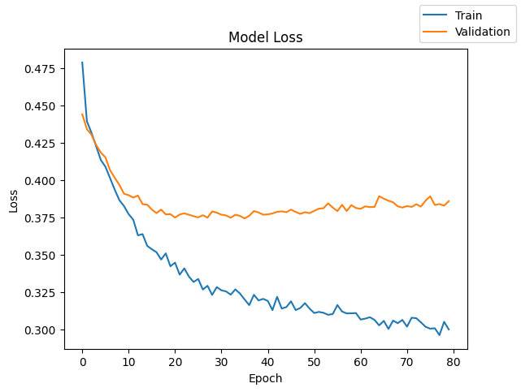

```python
# Plot Loss
plot(history_2, 'loss')
```

**Observation**

- Sharp initial loss decrease (0-10 epochs)
- Growing gap between training/validation after epoch 20
- Training loss continues declining
- Validation loss plateaus ~0.38 with slight increase
- Best validation performance around epoch 20
- Signs of overfitting after epoch 20
- Validation loss becomes unstable (small oscillations)

#### **Recall**

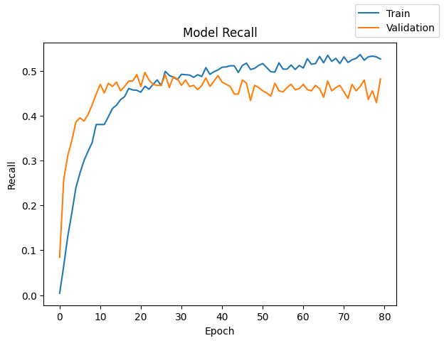

```python
# Plot Recall
plot(history_2, 'recall')
```

**Observation**

- Quick recall improvement until epoch 20
- Training recall stabilizes ~0.50-0.52
- Validation recall peaks early then declines to ~0.45
- Oscillating behavior in both curves
- Best validation recall around epoch 20-25

```
63/63 ━━━━━━━━━━━━━━━━━━━━ 0s 5ms/step
Best Threshold=0.263, G-Mean=0.766
```

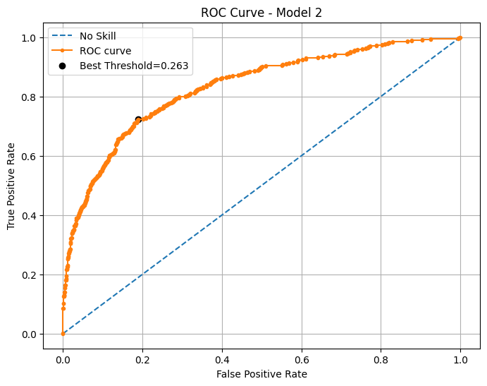

```
(0.2631444, 0.7658477310405636)
```

```python
# ROC
plot_roc_and_find_optimal_threshold(model_2, X_val, y_val, 'Model 2')
```

**Classification report**

```python
#Predicting the results using optimal threshold (Train set)
optimal_threshold = 0.5
model_2_train_perf, model_2_y_train_pred = model_performance_classification(model_2, X_train, y_train, optimal_threshold)
print("\nModel Performance on Training Set:")
print(model_2_train_perf.to_string(index=False))
```

```
188/188 ━━━━━━━━━━━━━━━━━━━━ 0s 1ms/step

Model Performance on Training Set:
 Accuracy  Recall  Precision  F1 Score
    0.888   0.888      0.883     0.883
```

```python
#Predicting the results using optimal threshold (Validation Set)
model_2_val_perf, model_2_y_val_pred = model_performance_classification(model_2, X_val, y_val, optimal_threshold)
print("\nModel Performance on Validation Set:")
print(model_2_val_perf.to_string(index=False))
```

```
63/63 ━━━━━━━━━━━━━━━━━━━━ 0s 1ms/step

Model Performance on Validation Set:
 Accuracy  Recall  Precision  F1 Score
    0.842   0.842      0.830     0.832
```

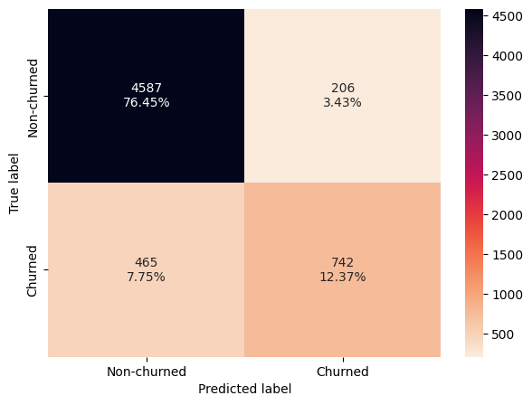

```
 Accuracy  Recall  Precision  F1 Score
    0.888   0.888      0.883     0.883
```

```python
# Confusion matrix for Train set
make_confusion_matrix(y_train, model_2_y_train_pred, model_2_train_perf)
```

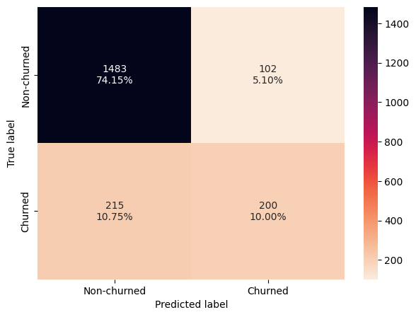

```
 Accuracy  Recall  Precision  F1 Score
    0.842   0.842      0.830     0.832
```

```python
# Confusion matrix for Validation set
make_confusion_matrix(y_val, model_2_y_val_pred, model_2_val_perf)
```

**Observation**

### Neural Network with Balanced Data (by applying SMOTE) and SGD Optimizer

**Let's try to apply SMOTE to balance this dataset and then again apply hyperparamter tuning accordingly.**

```python
# SMOTE to balance this dataset
smote = SMOTE(random_state=28)
X_train_smote, y_train_smote = smote.fit_resample(X_train, y_train)
print('Original shape of train_X: {}'.format(X_train.shape))
print('Original shape of train_y: {} \n'.format(y_train.shape))
print('After UpSampling, the shape of train_X: {}'.format(X_train_smote.shape))
print('After UpSampling, the shape of train_y: {} \n'.format(y_train_smote.shape))
```

```
Original shape of train_X: (6000, 11)
Original shape of train_y: (6000,)

After UpSampling, the shape of train_X: (9586, 11)
After UpSampling, the shape of train_y: (9586,)
```

**Model 3**

| Model | Model 3 - SGD Optimizer (Balanced dataset) |
| --- | --- |
| **Hidden layers** | 2 with 33 and 16 neurons respectively |
| **Activation function for Hidden layer** | ReLU |
| **Activation for output layer** | Sigmoid |
| **Optimizer** | SGD |
| **Learning rate** | 0.001 |
| **Loss function** | binary_crossentropy |
| **Metrics** | Accuracy, Recall |
| **Epochs** | 80 |
| **Batch Size** | 48 |

```python
# clears the current Keras session, resetting all layers and models previously created, freeing up memory and resources.
backend.clear_session()
#Fixing the seed for random number generators so that we can ensure we receive the same output everytime
np.random.seed(28)
random.seed(28)
tf.random.set_seed(28)
```

```python
# Initialize the Sequential Neural Network
model_3 = Sequential()
# Adding input layer with 66 nodes (6x number of features)
# input_dim automatically determined from training data shape
model_3.add(Dense(66, activation='relu', input_dim=X_train_smote.shape[1]))

# First hidden layer with 33 nodes (half of previous layer)
model_3.add(Dense(33, activation='relu'))

# Second hidden layer with 16 nodes (~half of previous layer)
model_3.add(Dense(16, activation='relu'))

# Output layer with sigmoid activation for binary classification
# Single node outputs probability between 0 and 1
model_3.add(Dense(1, activation='sigmoid'))
```

```python
# Compiling with SGD optimizer and binary cross entropy loss function.
optimizer = tf.keras.optimizers.SGD(learning_rate=0.001)
model_3.compile(optimizer=optimizer,
              loss='binary_crossentropy',
              metrics=['accuracy', tf.keras.metrics.Recall()])
```

```python
model_3.summary()
```

```
Model: "sequential"
```

```
┏━━━━━━━━━━━━━━━━━━━━━━━━━━━━━━━━━━━━━━┳━━━━━━━━━━━━━━━━━━━━━━━━━━━━━┳━━━━━━━━━━━━━━━━━┓
┃ Layer (type)                         ┃ Output Shape                ┃         Param # ┃
┡━━━━━━━━━━━━━━━━━━━━━━━━━━━━━━━━━━━━━━╇━━━━━━━━━━━━━━━━━━━━━━━━━━━━━╇━━━━━━━━━━━━━━━━━┩
│ dense (Dense)                        │ (None, 66)                  │             792 │
├──────────────────────────────────────┼─────────────────────────────┼─────────────────┤
│ dense_1 (Dense)                      │ (None, 33)                  │           2,211 │
├──────────────────────────────────────┼─────────────────────────────┼─────────────────┤
│ dense_2 (Dense)                      │ (None, 16)                  │             544 │
├──────────────────────────────────────┼─────────────────────────────┼─────────────────┤
│ dense_3 (Dense)                      │ (None, 1)                   │              17 │
└──────────────────────────────────────┴─────────────────────────────┴─────────────────┘
```

```
 Total params: 3,564 (13.92 KB)
```

```
 Trainable params: 3,564 (13.92 KB)
```

```
 Non-trainable params: 0 (0.00 B)
```

```python
# Fitting/Training the Neural Network
start = time.time()
history_3 = model_3.fit(
    X_train_smote, y_train_smote,
    batch_size=batch_size,
    validation_data=(X_val, y_val),  # Using validation set to monitor overfitting
    epochs=epochs,  # Training iterations
    verbose=1    # Show training progress
)
end = time.time()
print(f"Time taken: {end - start} seconds")
```

```
200/200 ━━━━━━━━━━━━━━━━━━━━ 5s 17ms/step - accuracy: 0.5102 - loss: 0.6937 - recall: 0.5556 - val_accuracy: 0.5220 - val_loss: 0.6927 - val_recall: 0.6217
200/200 ━━━━━━━━━━━━━━━━━━━━ 1s 5ms/step - accuracy: 0.5342 - loss: 0.6900 - recall: 0.5832 - val_accuracy: 0.5335 - val_loss: 0.6904 - val_recall: 0.6386
200/200 ━━━━━━━━━━━━━━━━━━━━ 1s 5ms/step - accuracy: 0.5541 - loss: 0.6865 - recall: 0.6074 - val_accuracy: 0.5500 - val_loss: 0.6884 - val_recall: 0.6458
200/200 ━━━━━━━━━━━━━━━━━━━━ 1s 3ms/step - accuracy: 0.5772 - loss: 0.6834 - recall: 0.6333 - val_accuracy: 0.5600 - val_loss: 0.6867 - val_recall: 0.6530
200/200 ━━━━━━━━━━━━━━━━━━━━ 1s 3ms/step - accuracy: 0.5953 - loss: 0.6803 - recall: 0.6531 - val_accuracy: 0.5710 - val_loss: 0.6852 - val_recall: 0.6675
200/200 ━━━━━━━━━━━━━━━━━━━━ 1s 3ms/step - accuracy: 0.6113 - loss: 0.6775 - recall: 0.6701 - val_accuracy: 0.5765 - val_loss: 0.6837 - val_recall: 0.6747
200/200 ━━━━━━━━━━━━━━━━━━━━ 1s 3ms/step - accuracy: 0.6204 - loss: 0.6748 - recall: 0.6778 - val_accuracy: 0.5895 - val_loss: 0.6822 - val_recall: 0.6819
200/200 ━━━━━━━━━━━━━━━━━━━━ 1s 3ms/step - accuracy: 0.6296 - loss: 0.6721 - recall: 0.6843 - val_accuracy: 0.6015 - val_loss: 0.6808 - val_recall: 0.6843
200/200 ━━━━━━━━━━━━━━━━━━━━ 1s 3ms/step - accuracy: 0.6374 - loss: 0.6695 - recall: 0.6943 - val_accuracy: 0.6080 - val_loss: 0.6795 - val_recall: 0.6867
200/200 ━━━━━━━━━━━━━━━━━━━━ 1s 3ms/step - accuracy: 0.6430 - loss: 0.6669 - recall: 0.6994 - val_accuracy: 0.6135 - val_loss: 0.6781 - val_recall: 0.6771
200/200 ━━━━━━━━━━━━━━━━━━━━ 1s 3ms/step - accuracy: 0.6482 - loss: 0.6642 - recall: 0.7013 - val_accuracy: 0.6230 - val_loss: 0.6767 - val_recall: 0.6747
200/200 ━━━━━━━━━━━━━━━━━━━━ 1s 3ms/step - accuracy: 0.6538 - loss: 0.6615 - recall: 0.7037 - val_accuracy: 0.6285 - val_loss: 0.6752 - val_recall: 0.6651
200/200 ━━━━━━━━━━━━━━━━━━━━ 1s 3ms/step - accuracy: 0.6600 - loss: 0.6588 - recall: 0.7095 - val_accuracy: 0.6330 - val_loss: 0.6736 - val_recall: 0.6651
200/200 ━━━━━━━━━━━━━━━━━━━━ 1s 3ms/step - accuracy: 0.6660 - loss: 0.6560 - recall: 0.7125 - val_accuracy: 0.6440 - val_loss: 0.6722 - val_recall: 0.6675
200/200 ━━━━━━━━━━━━━━━━━━━━ 1s 4ms/step - accuracy: 0.6738 - loss: 0.6530 - recall: 0.7182 - val_accuracy: 0.6505 - val_loss: 0.6706 - val_recall: 0.6699
200/200 ━━━━━━━━━━━━━━━━━━━━ 1s 6ms/step - accuracy: 0.6771 - loss: 0.6498 - recall: 0.7176 - val_accuracy: 0.6540 - val_loss: 0.6690 - val_recall: 0.6699
200/200 ━━━━━━━━━━━━━━━━━━━━ 1s 4ms/step - accuracy: 0.6811 - loss: 0.6466 - recall: 0.7160 - val_accuracy: 0.6595 - val_loss: 0.6671 - val_recall: 0.6723
200/200 ━━━━━━━━━━━━━━━━━━━━ 1s 3ms/step - accuracy: 0.6863 - loss: 0.6435 - recall: 0.7200 - val_accuracy: 0.6655 - val_loss: 0.6650 - val_recall: 0.6651
200/200 ━━━━━━━━━━━━━━━━━━━━ 1s 3ms/step - accuracy: 0.6912 - loss: 0.6403 - recall: 0.7203 - val_accuracy: 0.6695 - val_loss: 0.6626 - val_recall: 0.6602
200/200 ━━━━━━━━━━━━━━━━━━━━ 1s 3ms/step - accuracy: 0.6951 - loss: 0.6371 - recall: 0.7230 - val_accuracy: 0.6730 - val_loss: 0.6600 - val_recall: 0.6602
200/200 ━━━━━━━━━━━━━━━━━━━━ 1s 3ms/step - accuracy: 0.6961 - loss: 0.6341 - recall: 0.7193 - val_accuracy: 0.6760 - val_loss: 0.6571 - val_recall: 0.6578
200/200 ━━━━━━━━━━━━━━━━━━━━ 1s 3ms/step - accuracy: 0.6976 - loss: 0.6311 - recall: 0.7151 - val_accuracy: 0.6810 - val_loss: 0.6540 - val_recall: 0.6530
200/200 ━━━━━━━━━━━━━━━━━━━━ 1s 3ms/step - accuracy: 0.6989 - loss: 0.6281 - recall: 0.7123 - val_accuracy: 0.6860 - val_loss: 0.6507 - val_recall: 0.6506
200/200 ━━━━━━━━━━━━━━━━━━━━ 1s 3ms/step - accuracy: 0.7015 - loss: 0.6252 - recall: 0.7090 - val_accuracy: 0.6910 - val_loss: 0.6475 - val_recall: 0.6482
200/200 ━━━━━━━━━━━━━━━━━━━━ 1s 3ms/step - accuracy: 0.7036 - loss: 0.6223 - recall: 0.7089 - val_accuracy: 0.6960 - val_loss: 0.6442 - val_recall: 0.6482
200/200 ━━━━━━━━━━━━━━━━━━━━ 1s 3ms/step - accuracy: 0.7055 - loss: 0.6195 - recall: 0.7070 - val_accuracy: 0.7050 - val_loss: 0.6410 - val_recall: 0.6506
```

[output cut: 55 more lines]

#### **Loss Function**

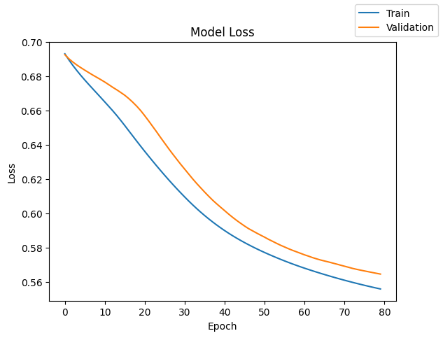

```python
# Plot Loss
plot(history_3, 'loss')
```

**Observation**

- Steady decrease in both training and validation loss
- Small, consistent gap between curves
- No signs of overfitting (parallel curves)
- Final loss values ~0.56-0.57
- Stable training behavior

#### **Recall**

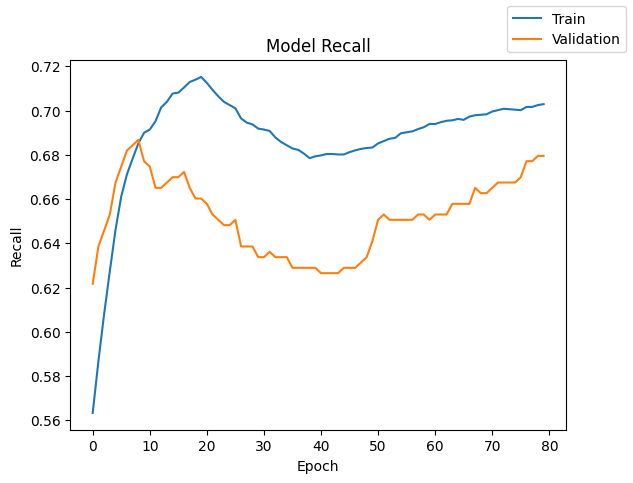

```python
# Plot Recall
plot(history_3, 'recall')
```

**Observation**

- Quick improvement to recall ~0.68 by epoch 10
- Training recall peaks at ~0.71 (epoch 20)
- Validation recall best at ~0.68 (epoch 10)
- Slight decline and recovery in both curves
- Best validation performance early (epoch 10)
- Some overfitting after epoch 20

```
63/63 ━━━━━━━━━━━━━━━━━━━━ 0s 4ms/step
Best Threshold=0.483, G-Mean=0.712
```

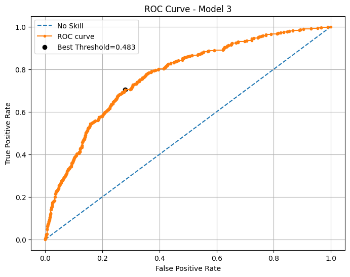

```
(0.4825865, 0.7116977065298422)
```

```python
# ROC
plot_roc_and_find_optimal_threshold(model_3, X_val, y_val, 'Model 3')
```

**Classification report**

```python
#Predicting the results using optimal threshold (Train set)
optimal_threshold = 0.483
model_3_train_perf, model_3_y_train_pred = model_performance_classification(model_3, X_train_smote, y_train_smote, optimal_threshold)
print("\nModel Performance on Training Set:")
print(model_3_train_perf.to_string(index=False))
```

```
300/300 ━━━━━━━━━━━━━━━━━━━━ 1s 2ms/step

Model Performance on Training Set:
 Accuracy  Recall  Precision  F1 Score
    0.723   0.723      0.723     0.723
```

```python
#Predicting the results using optimal threshold (Validation Set)
model_3_val_perf, model_3_y_val_pred = model_performance_classification(model_3, X_val, y_val, optimal_threshold)
print("\nModel Performance on Validation Set:")
print(model_3_val_perf.to_string(index=False))
```

```
63/63 ━━━━━━━━━━━━━━━━━━━━ 0s 1ms/step

Model Performance on Validation Set:
 Accuracy  Recall  Precision  F1 Score
    0.716   0.716      0.796     0.739
```

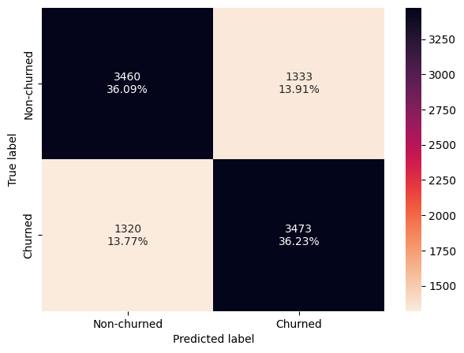

```
 Accuracy  Recall  Precision  F1 Score
    0.723   0.723      0.723     0.723
```

```python
# Confusion matrix for Train set
make_confusion_matrix(y_train_smote, model_3_y_train_pred, model_3_train_perf)
```

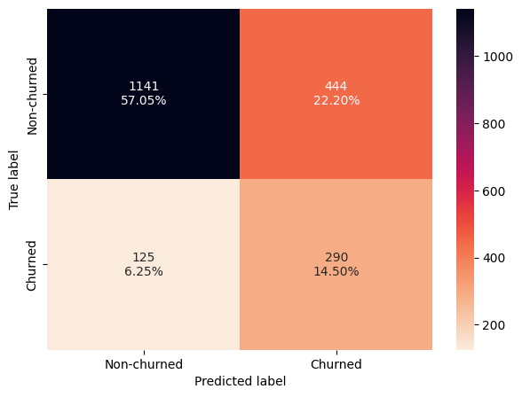

```
 Accuracy  Recall  Precision  F1 Score
    0.716   0.716      0.796     0.739
```

```python
# Confusion matrix for Validation set
make_confusion_matrix(y_val, model_3_y_val_pred, model_3_val_perf)
```

**Observation**

- Training Set:
  - True Negatives: 3460 (36.09%)
  - True Positives: 3473 (36.23%)
  - False Negatives: 1320 (13.77%)
  - Balanced metrics: Accuracy/Recall/Precision all 0.723
- Validation Set:
  - True Negatives: 1141 (57.05%)
  - True Positives: 290 (14.50%)
  - Higher False Positives: 444 (22.20%)
  - Good metrics: Accuracy 0.716, Recall 0.716, F1 0.739
- Key Observation:
  - More balanced predictions between classes
  - Consistent performance between metrics
  - Higher false positives in validation set
  - Good generalization overall

### Neural Network with Balanced Data (by applying SMOTE) and Adam Optimizer

**Model 4**

| Model | Model 4 - Adam Optimizer (Balanced dataset) |
| --- | --- |
| **Hidden layers** | 2 with 33 and 16 neurons respectively |
| **Activation function for Hidden layer** | ReLU |
| **Activation for output layer** | Sigmoid |
| **Optimizer** | Adam |
| **Learning rate** | 0.001 |
| **Loss function** | binary_crossentropy |
| **Metrics** | Accuracy, Recall |
| **Epochs** | 80 |
| **Batch Size** | 48 |

```python
# clears the current Keras session, resetting all layers and models previously created, freeing up memory and resources.
backend.clear_session()
#Fixing the seed for random number generators so that we can ensure we receive the same output everytime
np.random.seed(28)
random.seed(28)
tf.random.set_seed(28)
```

```python
# Initialize the Sequential Neural Network
model_4 = Sequential()
# Adding input layer with 66 nodes (6x number of features)
# input_dim automatically determined from training data shape
model_4.add(Dense(66, activation='relu', input_dim=X_train_smote.shape[1]))

# First hidden layer with 33 nodes (half of previous layer)
model_4.add(Dense(33, activation='relu'))

# Second hidden layer with 16 nodes (~half of previous layer)
model_4.add(Dense(16, activation='relu'))

# Output layer with sigmoid activation for binary classification
# Single node outputs probability between 0 and 1
model_4.add(Dense(1, activation='sigmoid'))
```

```python
# Compiling with Adam optimizer and binary cross entropy loss function.
optimizer = tf.keras.optimizers.Adam(learning_rate=0.001)
model_4.compile(optimizer=optimizer,
              loss='binary_crossentropy',
              metrics=['accuracy', tf.keras.metrics.Recall()])
```

```python
model_4.summary()
```

```
Model: "sequential"
```

```
┏━━━━━━━━━━━━━━━━━━━━━━━━━━━━━━━━━━━━━━┳━━━━━━━━━━━━━━━━━━━━━━━━━━━━━┳━━━━━━━━━━━━━━━━━┓
┃ Layer (type)                         ┃ Output Shape                ┃         Param # ┃
┡━━━━━━━━━━━━━━━━━━━━━━━━━━━━━━━━━━━━━━╇━━━━━━━━━━━━━━━━━━━━━━━━━━━━━╇━━━━━━━━━━━━━━━━━┩
│ dense (Dense)                        │ (None, 66)                  │             792 │
├──────────────────────────────────────┼─────────────────────────────┼─────────────────┤
│ dense_1 (Dense)                      │ (None, 33)                  │           2,211 │
├──────────────────────────────────────┼─────────────────────────────┼─────────────────┤
│ dense_2 (Dense)                      │ (None, 16)                  │             544 │
├──────────────────────────────────────┼─────────────────────────────┼─────────────────┤
│ dense_3 (Dense)                      │ (None, 1)                   │              17 │
└──────────────────────────────────────┴─────────────────────────────┴─────────────────┘
```

```
 Total params: 3,564 (13.92 KB)
```

```
 Trainable params: 3,564 (13.92 KB)
```

```
 Non-trainable params: 0 (0.00 B)
```

```python
# Fitting/Training the Neural Network
start = time.time()
history_4 = model_4.fit(
    X_train_smote, y_train_smote,
    batch_size=batch_size,
    validation_data=(X_val, y_val),  # Using validation set to monitor overfitting
    epochs=epochs,  # Training iterations
    verbose=1    # Show training progress
)
end = time.time()
print(f"Time taken: {end - start} seconds")
```

```
200/200 ━━━━━━━━━━━━━━━━━━━━ 5s 11ms/step - accuracy: 0.6670 - loss: 0.6242 - recall: 0.6897 - val_accuracy: 0.7260 - val_loss: 0.5556 - val_recall: 0.7325
200/200 ━━━━━━━━━━━━━━━━━━━━ 2s 3ms/step - accuracy: 0.7460 - loss: 0.5212 - recall: 0.7424 - val_accuracy: 0.7450 - val_loss: 0.5277 - val_recall: 0.7229
200/200 ━━━━━━━━━━━━━━━━━━━━ 1s 3ms/step - accuracy: 0.7778 - loss: 0.4828 - recall: 0.7804 - val_accuracy: 0.7405 - val_loss: 0.5150 - val_recall: 0.7157
200/200 ━━━━━━━━━━━━━━━━━━━━ 1s 3ms/step - accuracy: 0.7871 - loss: 0.4570 - recall: 0.7959 - val_accuracy: 0.7490 - val_loss: 0.5010 - val_recall: 0.7108
200/200 ━━━━━━━━━━━━━━━━━━━━ 1s 3ms/step - accuracy: 0.7932 - loss: 0.4381 - recall: 0.8017 - val_accuracy: 0.7600 - val_loss: 0.4925 - val_recall: 0.7060
200/200 ━━━━━━━━━━━━━━━━━━━━ 1s 3ms/step - accuracy: 0.8013 - loss: 0.4228 - recall: 0.8119 - val_accuracy: 0.7710 - val_loss: 0.4903 - val_recall: 0.7084
200/200 ━━━━━━━━━━━━━━━━━━━━ 1s 3ms/step - accuracy: 0.8094 - loss: 0.4096 - recall: 0.8169 - val_accuracy: 0.7660 - val_loss: 0.4959 - val_recall: 0.7108
200/200 ━━━━━━━━━━━━━━━━━━━━ 1s 3ms/step - accuracy: 0.8141 - loss: 0.3983 - recall: 0.8227 - val_accuracy: 0.7665 - val_loss: 0.4934 - val_recall: 0.7060
200/200 ━━━━━━━━━━━━━━━━━━━━ 1s 3ms/step - accuracy: 0.8194 - loss: 0.3886 - recall: 0.8269 - val_accuracy: 0.7650 - val_loss: 0.4971 - val_recall: 0.7084
200/200 ━━━━━━━━━━━━━━━━━━━━ 2s 5ms/step - accuracy: 0.8246 - loss: 0.3796 - recall: 0.8312 - val_accuracy: 0.7640 - val_loss: 0.5021 - val_recall: 0.7157
200/200 ━━━━━━━━━━━━━━━━━━━━ 1s 5ms/step - accuracy: 0.8285 - loss: 0.3719 - recall: 0.8341 - val_accuracy: 0.7620 - val_loss: 0.5098 - val_recall: 0.7205
200/200 ━━━━━━━━━━━━━━━━━━━━ 1s 5ms/step - accuracy: 0.8307 - loss: 0.3651 - recall: 0.8339 - val_accuracy: 0.7640 - val_loss: 0.5088 - val_recall: 0.7205
200/200 ━━━━━━━━━━━━━━━━━━━━ 1s 3ms/step - accuracy: 0.8364 - loss: 0.3587 - recall: 0.8428 - val_accuracy: 0.7600 - val_loss: 0.5103 - val_recall: 0.7157
200/200 ━━━━━━━━━━━━━━━━━━━━ 1s 3ms/step - accuracy: 0.8385 - loss: 0.3527 - recall: 0.8448 - val_accuracy: 0.7555 - val_loss: 0.5192 - val_recall: 0.7229
200/200 ━━━━━━━━━━━━━━━━━━━━ 1s 3ms/step - accuracy: 0.8429 - loss: 0.3470 - recall: 0.8480 - val_accuracy: 0.7555 - val_loss: 0.5225 - val_recall: 0.7253
200/200 ━━━━━━━━━━━━━━━━━━━━ 1s 3ms/step - accuracy: 0.8470 - loss: 0.3413 - recall: 0.8561 - val_accuracy: 0.7560 - val_loss: 0.5275 - val_recall: 0.7253
200/200 ━━━━━━━━━━━━━━━━━━━━ 1s 3ms/step - accuracy: 0.8513 - loss: 0.3353 - recall: 0.8593 - val_accuracy: 0.7530 - val_loss: 0.5318 - val_recall: 0.7229
200/200 ━━━━━━━━━━━━━━━━━━━━ 1s 3ms/step - accuracy: 0.8520 - loss: 0.3299 - recall: 0.8606 - val_accuracy: 0.7530 - val_loss: 0.5342 - val_recall: 0.7205
200/200 ━━━━━━━━━━━━━━━━━━━━ 1s 3ms/step - accuracy: 0.8546 - loss: 0.3244 - recall: 0.8628 - val_accuracy: 0.7535 - val_loss: 0.5335 - val_recall: 0.7181
200/200 ━━━━━━━━━━━━━━━━━━━━ 1s 3ms/step - accuracy: 0.8583 - loss: 0.3193 - recall: 0.8667 - val_accuracy: 0.7480 - val_loss: 0.5398 - val_recall: 0.7084
200/200 ━━━━━━━━━━━━━━━━━━━━ 1s 3ms/step - accuracy: 0.8593 - loss: 0.3135 - recall: 0.8671 - val_accuracy: 0.7490 - val_loss: 0.5453 - val_recall: 0.7181
200/200 ━━━━━━━━━━━━━━━━━━━━ 2s 5ms/step - accuracy: 0.8636 - loss: 0.3089 - recall: 0.8734 - val_accuracy: 0.7505 - val_loss: 0.5420 - val_recall: 0.7133
200/200 ━━━━━━━━━━━━━━━━━━━━ 1s 5ms/step - accuracy: 0.8670 - loss: 0.3035 - recall: 0.8747 - val_accuracy: 0.7465 - val_loss: 0.5518 - val_recall: 0.7108
200/200 ━━━━━━━━━━━━━━━━━━━━ 1s 5ms/step - accuracy: 0.8710 - loss: 0.2986 - recall: 0.8788 - val_accuracy: 0.7450 - val_loss: 0.5577 - val_recall: 0.7157
200/200 ━━━━━━━━━━━━━━━━━━━━ 1s 3ms/step - accuracy: 0.8748 - loss: 0.2946 - recall: 0.8847 - val_accuracy: 0.7495 - val_loss: 0.5596 - val_recall: 0.7181
200/200 ━━━━━━━━━━━━━━━━━━━━ 1s 3ms/step - accuracy: 0.8784 - loss: 0.2898 - recall: 0.8876 - val_accuracy: 0.7490 - val_loss: 0.5640 - val_recall: 0.7205
```

[output cut: 55 more lines]

#### **Loss Function**

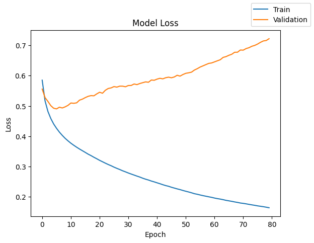

```python
# Plot Loss
plot(history_4, 'loss')
```

**Observation**

- Training loss steadily decreases
- Validation loss increases significantly after epoch 20
- Large and growing gap between curves
- Clear sign of severe overfitting

#### **Recall**

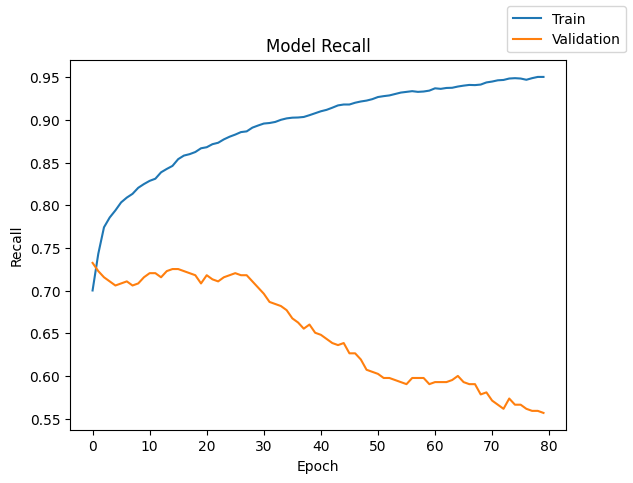

```python
# Plot Recall
plot(history_4, 'recall')
```

**Observation**

```
63/63 ━━━━━━━━━━━━━━━━━━━━ 0s 4ms/step
Best Threshold=0.116, G-Mean=0.722
```

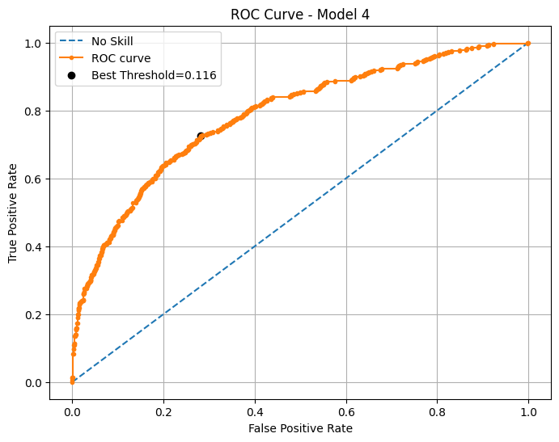

```
(0.11629729, 0.7219488487735988)
```

```python
# ROC
plot_roc_and_find_optimal_threshold(model_4, X_val, y_val, 'Model 4')
```

**Classification report**

```python
#Predicting the results using optimal threshold (Train set)
optimal_threshold = 0.5
model_4_train_perf, model_4_y_train_pred = model_performance_classification(model_4, X_train_smote, y_train_smote, optimal_threshold)
print("\nModel Performance on Training Set:")
print(model_4_train_perf.to_string(index=False))
```

```
300/300 ━━━━━━━━━━━━━━━━━━━━ 0s 2ms/step

Model Performance on Training Set:
 Accuracy  Recall  Precision  F1 Score
    0.934   0.934      0.935     0.934
```

```python
#Predicting the results using optimal threshold (Validation Set)
model_4_val_perf, model_4_y_val_pred = model_performance_classification(model_4, X_val, y_val, optimal_threshold)
print("\nModel Performance on Validation Set:")
print(model_4_val_perf.to_string(index=False))
```

```
63/63 ━━━━━━━━━━━━━━━━━━━━ 0s 1ms/step

Model Performance on Validation Set:
 Accuracy  Recall  Precision  F1 Score
    0.790   0.790      0.800     0.794
```

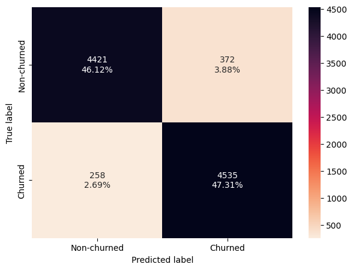

```
 Accuracy  Recall  Precision  F1 Score
    0.934   0.934      0.935     0.934
```

```python
# Confusion matrix for Train set
make_confusion_matrix(y_train_smote, model_4_y_train_pred, model_4_train_perf)
```

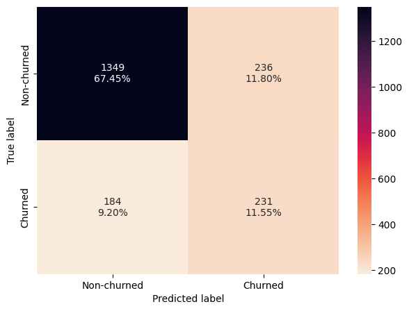

```
 Accuracy  Recall  Precision  F1 Score
    0.790   0.790      0.800     0.794
```

```python
# Confusion matrix for Validation set
make_confusion_matrix(y_val, model_4_y_val_pred, model_4_val_perf)
```

**Observation**

### Neural Network with Balanced Data (by applying SMOTE), Adam Optimizer, and Dropout

**Model 5**

[output not shown]

```python
# clears the current Keras session, resetting all layers and models previously created, freeing up memory and resources.
backend.clear_session()
#Fixing the seed for random number generators so that we can ensure we receive the same output everytime
np.random.seed(28)
random.seed(28)
tf.random.set_seed(28)
```

```python
# Initialize the Sequential Neural Network
# Initialize the Sequential Neural Network
model_5 = Sequential()

# Adding input layer with 66 nodes (6x number of features)
# input_dim automatically determined from training data shape
model_5.add(Dense(66, activation='relu', input_dim=X_train_smote.shape[1]))

# Add dropout layer to prevent overfitting (20% dropout rate)
model_5.add(Dropout(0.2))

# First hidden layer with 33 nodes (half of previous layer)
model_5.add(Dense(33, activation='relu'))

# Another dropout layer for regularization
model_5.add(Dropout(0.2))

# Second hidden layer with 16 nodes (~half of previous layer)
model_5.add(Dense(16, activation='relu'))

# Output layer with sigmoid activation for binary classification
# Single node outputs probability between 0 and 1
model_5.add(Dense(1, activation='sigmoid'))
```

```python
# Compiling with Adam optimizer and binary cross entropy loss function.
optimizer = tf.keras.optimizers.Adam(learning_rate=0.001)
model_5.compile(optimizer=optimizer,
              loss='binary_crossentropy',
              metrics=['accuracy', tf.keras.metrics.Recall()])
```

```python
model_5.summary()
```

```
Model: "sequential"
```

```
┏━━━━━━━━━━━━━━━━━━━━━━━━━━━━━━━━━━━━━━┳━━━━━━━━━━━━━━━━━━━━━━━━━━━━━┳━━━━━━━━━━━━━━━━━┓
┃ Layer (type)                         ┃ Output Shape                ┃         Param # ┃
┡━━━━━━━━━━━━━━━━━━━━━━━━━━━━━━━━━━━━━━╇━━━━━━━━━━━━━━━━━━━━━━━━━━━━━╇━━━━━━━━━━━━━━━━━┩
│ dense (Dense)                        │ (None, 66)                  │             792 │
├──────────────────────────────────────┼─────────────────────────────┼─────────────────┤
│ dropout (Dropout)                    │ (None, 66)                  │               0 │
├──────────────────────────────────────┼─────────────────────────────┼─────────────────┤
│ dense_1 (Dense)                      │ (None, 33)                  │           2,211 │
├──────────────────────────────────────┼─────────────────────────────┼─────────────────┤
│ dropout_1 (Dropout)                  │ (None, 33)                  │               0 │
├──────────────────────────────────────┼─────────────────────────────┼─────────────────┤
│ dense_2 (Dense)                      │ (None, 16)                  │             544 │
├──────────────────────────────────────┼─────────────────────────────┼─────────────────┤
│ dense_3 (Dense)                      │ (None, 1)                   │              17 │
└──────────────────────────────────────┴─────────────────────────────┴─────────────────┘
```

```
 Total params: 3,564 (13.92 KB)
```

```
 Trainable params: 3,564 (13.92 KB)
```

```
 Non-trainable params: 0 (0.00 B)
```

```python
# Fitting/Training the Neural Network
start = time.time()
history_5 = model_5.fit(
    X_train_smote, y_train_smote,
    batch_size=batch_size,
    validation_data=(X_val, y_val),  # Using validation set to monitor overfitting
    epochs=epochs,  # Training iterations
    verbose=1    # Show training progress
)
end = time.time()
print(f"Time taken: {end - start} seconds")
```

```
200/200 ━━━━━━━━━━━━━━━━━━━━ 6s 13ms/step - accuracy: 0.6226 - loss: 0.6480 - recall: 0.4477 - val_accuracy: 0.6905 - val_loss: 0.5946 - val_recall: 0.7518
200/200 ━━━━━━━━━━━━━━━━━━━━ 1s 3ms/step - accuracy: 0.7238 - loss: 0.5656 - recall: 0.7484 - val_accuracy: 0.7010 - val_loss: 0.5702 - val_recall: 0.7373
200/200 ━━━━━━━━━━━━━━━━━━━━ 1s 4ms/step - accuracy: 0.7323 - loss: 0.5464 - recall: 0.7386 - val_accuracy: 0.7365 - val_loss: 0.5490 - val_recall: 0.7229
200/200 ━━━━━━━━━━━━━━━━━━━━ 1s 5ms/step - accuracy: 0.7452 - loss: 0.5274 - recall: 0.7457 - val_accuracy: 0.7555 - val_loss: 0.5329 - val_recall: 0.7205
200/200 ━━━━━━━━━━━━━━━━━━━━ 1s 5ms/step - accuracy: 0.7567 - loss: 0.5068 - recall: 0.7504 - val_accuracy: 0.7410 - val_loss: 0.5351 - val_recall: 0.7422
200/200 ━━━━━━━━━━━━━━━━━━━━ 1s 6ms/step - accuracy: 0.7613 - loss: 0.4969 - recall: 0.7704 - val_accuracy: 0.7470 - val_loss: 0.5167 - val_recall: 0.7253
200/200 ━━━━━━━━━━━━━━━━━━━━ 1s 3ms/step - accuracy: 0.7727 - loss: 0.4748 - recall: 0.7850 - val_accuracy: 0.7505 - val_loss: 0.5058 - val_recall: 0.7205
200/200 ━━━━━━━━━━━━━━━━━━━━ 1s 3ms/step - accuracy: 0.7800 - loss: 0.4720 - recall: 0.7904 - val_accuracy: 0.7400 - val_loss: 0.5210 - val_recall: 0.7590
200/200 ━━━━━━━━━━━━━━━━━━━━ 1s 3ms/step - accuracy: 0.7844 - loss: 0.4648 - recall: 0.7923 - val_accuracy: 0.7480 - val_loss: 0.5151 - val_recall: 0.7518
200/200 ━━━━━━━━━━━━━━━━━━━━ 1s 3ms/step - accuracy: 0.7866 - loss: 0.4581 - recall: 0.8073 - val_accuracy: 0.7540 - val_loss: 0.5023 - val_recall: 0.7446
200/200 ━━━━━━━━━━━━━━━━━━━━ 1s 3ms/step - accuracy: 0.7933 - loss: 0.4489 - recall: 0.8091 - val_accuracy: 0.7535 - val_loss: 0.5040 - val_recall: 0.7566
200/200 ━━━━━━━━━━━━━━━━━━━━ 1s 3ms/step - accuracy: 0.7932 - loss: 0.4405 - recall: 0.8099 - val_accuracy: 0.7690 - val_loss: 0.4893 - val_recall: 0.7590
200/200 ━━━━━━━━━━━━━━━━━━━━ 1s 3ms/step - accuracy: 0.7902 - loss: 0.4406 - recall: 0.8052 - val_accuracy: 0.7615 - val_loss: 0.4939 - val_recall: 0.7398
200/200 ━━━━━━━━━━━━━━━━━━━━ 1s 3ms/step - accuracy: 0.8005 - loss: 0.4336 - recall: 0.8185 - val_accuracy: 0.7590 - val_loss: 0.4870 - val_recall: 0.7446
200/200 ━━━━━━━━━━━━━━━━━━━━ 1s 3ms/step - accuracy: 0.8036 - loss: 0.4262 - recall: 0.8238 - val_accuracy: 0.7590 - val_loss: 0.4934 - val_recall: 0.7542
200/200 ━━━━━━━━━━━━━━━━━━━━ 1s 3ms/step - accuracy: 0.7987 - loss: 0.4279 - recall: 0.8169 - val_accuracy: 0.7705 - val_loss: 0.4831 - val_recall: 0.7566
200/200 ━━━━━━━━━━━━━━━━━━━━ 1s 3ms/step - accuracy: 0.8030 - loss: 0.4251 - recall: 0.8179 - val_accuracy: 0.7630 - val_loss: 0.4910 - val_recall: 0.7590
200/200 ━━━━━━━━━━━━━━━━━━━━ 1s 4ms/step - accuracy: 0.8020 - loss: 0.4235 - recall: 0.8198 - val_accuracy: 0.7690 - val_loss: 0.4767 - val_recall: 0.7422
200/200 ━━━━━━━━━━━━━━━━━━━━ 1s 5ms/step - accuracy: 0.8095 - loss: 0.4158 - recall: 0.8290 - val_accuracy: 0.7705 - val_loss: 0.4778 - val_recall: 0.7422
200/200 ━━━━━━━━━━━━━━━━━━━━ 1s 5ms/step - accuracy: 0.8105 - loss: 0.4142 - recall: 0.8249 - val_accuracy: 0.7680 - val_loss: 0.4819 - val_recall: 0.7422
200/200 ━━━━━━━━━━━━━━━━━━━━ 1s 5ms/step - accuracy: 0.8099 - loss: 0.4133 - recall: 0.8249 - val_accuracy: 0.7730 - val_loss: 0.4753 - val_recall: 0.7494
200/200 ━━━━━━━━━━━━━━━━━━━━ 1s 3ms/step - accuracy: 0.8160 - loss: 0.4037 - recall: 0.8323 - val_accuracy: 0.7750 - val_loss: 0.4793 - val_recall: 0.7422
200/200 ━━━━━━━━━━━━━━━━━━━━ 1s 3ms/step - accuracy: 0.8145 - loss: 0.4051 - recall: 0.8366 - val_accuracy: 0.7735 - val_loss: 0.4752 - val_recall: 0.7446
200/200 ━━━━━━━━━━━━━━━━━━━━ 1s 3ms/step - accuracy: 0.8183 - loss: 0.4045 - recall: 0.8284 - val_accuracy: 0.7630 - val_loss: 0.4901 - val_recall: 0.7542
200/200 ━━━━━━━━━━━━━━━━━━━━ 1s 3ms/step - accuracy: 0.8171 - loss: 0.3959 - recall: 0.8366 - val_accuracy: 0.7715 - val_loss: 0.4828 - val_recall: 0.7349
200/200 ━━━━━━━━━━━━━━━━━━━━ 1s 3ms/step - accuracy: 0.8216 - loss: 0.3939 - recall: 0.8353 - val_accuracy: 0.7700 - val_loss: 0.4810 - val_recall: 0.7398
```

[output cut: 55 more lines]

#### **Loss Function**

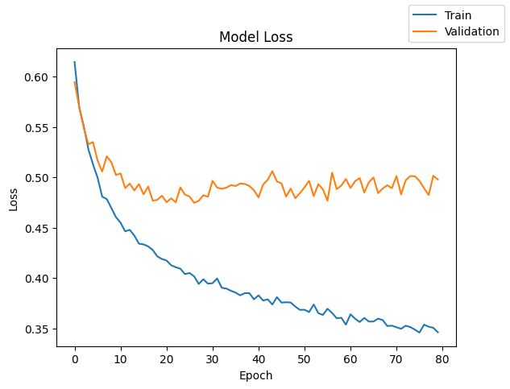

```python
# Plot Loss
plot(history_5, 'loss')
```

**Observation**

- Training loss steadily decreases
- Validation loss plateaus after epoch 20
- Growing gap between training/validation
- Validation shows oscillations
- Clear overfitting pattern after epoch 20

#### **Recall**

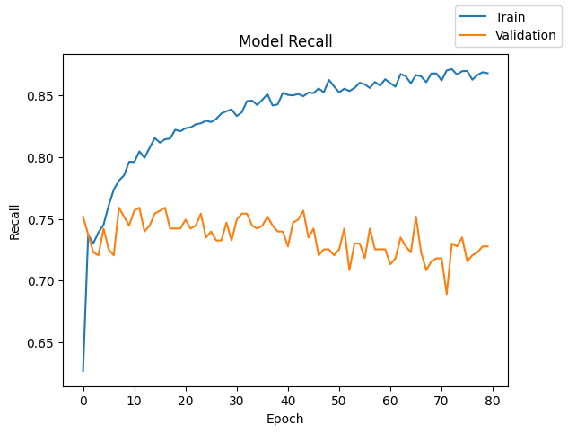

```python
# Plot Recall
plot(history_5, 'recall')
```

**Observation**

- Training recall steadily increases to ~0.87
- Validation recall peaks early (~0.75) then declines
- Growing gap between curves
- High validation oscillations

```
63/63 ━━━━━━━━━━━━━━━━━━━━ 0s 4ms/step
Best Threshold=0.540, G-Mean=0.762
```

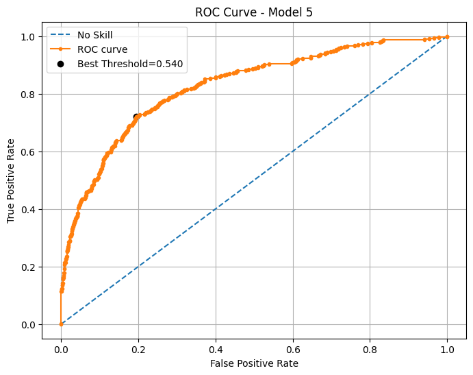

```
(0.5396971, 0.7621884081202259)
```

```python
# ROC
plot_roc_and_find_optimal_threshold(model_5, X_val, y_val, 'Model 5')
```

**Classification report**

```python
#Predicting the results using optimal threshold (Train set)
optimal_threshold = 0.459
model_5_train_perf, model_5_y_train_pred = model_performance_classification(model_5, X_train_smote, y_train_smote, optimal_threshold)
print("\nModel Performance on Training Set:")
print(model_5_train_perf.to_string(index=False))
```

```
300/300 ━━━━━━━━━━━━━━━━━━━━ 0s 2ms/step

Model Performance on Training Set:
 Accuracy  Recall  Precision  F1 Score
    0.875   0.875      0.883     0.874
```

```python
#Predicting the results using optimal threshold (Validation Set)
model_5_val_perf, model_5_y_val_pred = model_performance_classification(model_5, X_val, y_val, optimal_threshold)
print("\nModel Performance on Validation Set:")
print(model_5_val_perf.to_string(index=False))
```

```
63/63 ━━━━━━━━━━━━━━━━━━━━ 0s 2ms/step

Model Performance on Validation Set:
 Accuracy  Recall  Precision  F1 Score
    0.762   0.762      0.823     0.780
```

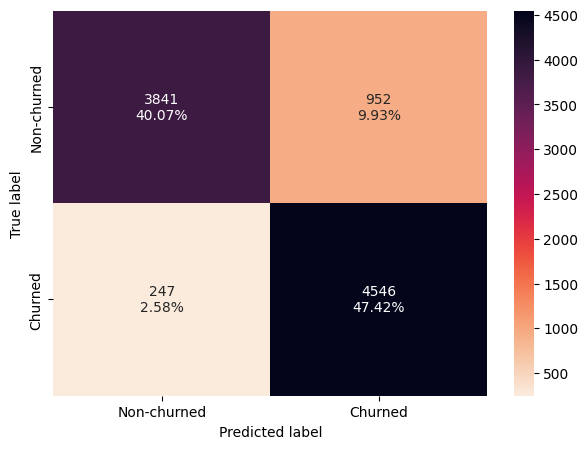

```
 Accuracy  Recall  Precision  F1 Score
    0.875   0.875      0.883     0.874
```

```python
# Confusion matrix for Train set
make_confusion_matrix(y_train_smote, model_5_y_train_pred, model_5_train_perf)
```

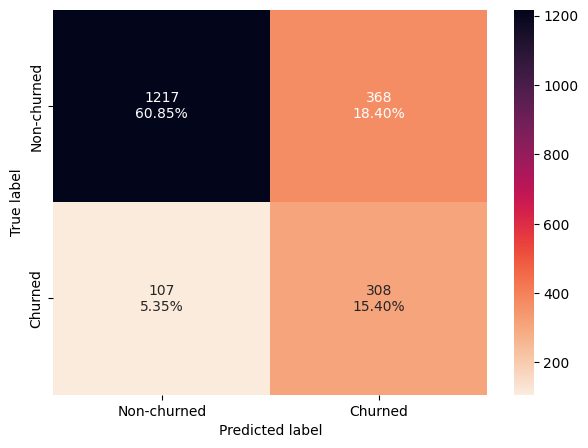

```
 Accuracy  Recall  Precision  F1 Score
    0.762   0.762      0.823     0.780
```

```python
# Confusion matrix for Validation set
make_confusion_matrix(y_val, model_5_y_val_pred, model_5_val_perf)
```

**Observation**

## Model Performance Comparison and Final Model Selection

```python
#Validation performance comparison

models_train_comp_df = pd.concat(
    [
        model_0_train_perf.T,
        model_1_train_perf.T,
        model_2_train_perf.T,
        model_3_train_perf.T,
        model_4_train_perf.T,
        model_5_train_perf.T
    ],
    axis=1,
)
models_train_comp_df.columns = [
    "ANN SGD - No Regularization",
    "ANN Adam - No Regularization",
    "ANN Adam - Dropout [0.2,0.2]",
    "ANN SGD - SMOTE",
    "ANN Adam - SMOTE",
    "ANN Adam - Balancedropout [0.2,0.2] - SMOTE"
]
```

```python
#Validation performance comparison

models_val_comp_df = pd.concat(
    [
        model_0_val_perf.T,
        model_1_val_perf.T,
        model_2_val_perf.T,
        model_3_val_perf.T,
        model_4_val_perf.T,
        model_5_val_perf.T
    ],
    axis=1,
)
models_val_comp_df.columns = [
    "ANN SGD - No Regularization",
    "ANN Adam - No Regularization",
    "ANN Adam - Dropout [0.2,0.2]",
    "ANN SGD - SMOTE",
    "ANN Adam - SMOTE",
    "ANN Adam - Balancedropout [0.2,0.2] - SMOTE"
]
```

```python
print("Training Performance Comparison:")
models_train_comp_df
```

```
Training Performance Comparison:
```

|  | ANN SGD - No Regularization | ANN Adam - No Regularization | ANN Adam - Dropout [0.2,0.2] | ANN SGD - SMOTE | ANN Adam - SMOTE | ANN Adam - Balancedropout [0.2,0.2] - SMOTE |
| --- | --- | --- | --- | --- | --- | --- |
| Accuracy | 0.806 | 0.890 | 0.888 | 0.723 | 0.934 | 0.875 |
| Recall | 0.806 | 0.890 | 0.888 | 0.723 | 0.934 | 0.875 |
| Precision | 0.769 | 0.889 | 0.883 | 0.723 | 0.935 | 0.883 |
| F1 Score | 0.751 | 0.890 | 0.883 | 0.723 | 0.934 | 0.874 |

```python
print("\nValidation Performance Comparison:")
models_val_comp_df
```

```
Validation Performance Comparison:
```

|  | ANN SGD - No Regularization | ANN Adam - No Regularization | ANN Adam - Dropout [0.2,0.2] | ANN SGD - SMOTE | ANN Adam - SMOTE | ANN Adam - Balancedropout [0.2,0.2] - SMOTE |
| --- | --- | --- | --- | --- | --- | --- |
| Accuracy | 0.796 | 0.815 | 0.842 | 0.716 | 0.790 | 0.762 |
| Recall | 0.796 | 0.815 | 0.842 | 0.716 | 0.790 | 0.762 |
| Precision | 0.753 | 0.814 | 0.830 | 0.796 | 0.800 | 0.823 |
| F1 Score | 0.737 | 0.814 | 0.832 | 0.739 | 0.794 | 0.780 |

**Observation**

**Model Comparisons:**

- Basic Models (No Regularization):
  - SGD performs worst
  - Adam shows improvement but overfits
- SMOTE Models:
  - Improved recall but lower overall metrics
  - More balanced predictions
- Dropout Models:
  - Best validation performance
  - Good generalization
  - Most stable metrics

**Recommendations:**

Use **ANN Adam with Dropout** as final model

The dropout model provides the best combination of high performance and good generalization.

**Let's check the performance of Adam with Dropout on test data**

**Classification report**

```python
#Predicting the results using optimal threshold (Test Set)
model_2_test_perf, model_2_y_test_pred = model_performance_classification(model_2, X_test, y_test, optimal_threshold)
print("\nModel Performance on Test Set:")
print(model_2_test_perf.to_string(index=False))
```

```
63/63 ━━━━━━━━━━━━━━━━━━━━ 0s 2ms/step

Model Performance on Test Set:
 Accuracy  Recall  Precision  F1 Score
    0.865   0.865      0.857     0.858
```

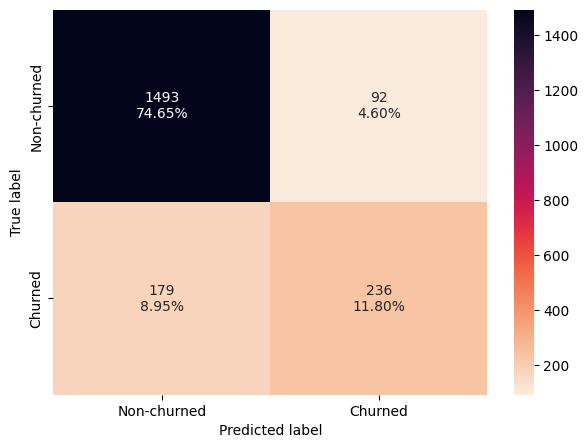

```
 Accuracy  Recall  Precision  F1 Score
    0.865   0.865      0.857     0.858
```

```python
# Confusion matrix for Train set
make_confusion_matrix(y_test, model_2_y_test_pred, model_2_test_perf)
```

**Observation**

- Matrix Breakdown:
  - True Negatives (TN): 1493 (74.65%) - Correctly identified non-churners
  - False Positives (FP): 92 (4.60%) - Incorrectly predicted as churners
  - False Negatives (FN): 179 (8.95%) - Missed churners
  - True Positives (TP): 236 (11.80%) - Correctly identified churners
- Performance Metrics:
  - Accuracy: 0.865 (86.5%)
  - Recall: 0.865 (86.5%)
  - Precision: 0.857 (85.7%)
  - F1 Score: 0.858 (85.8%)
- Key Observations:
  - Strong balanced performance across all metrics
  - Low false positive rate is good for targeted retention efforts
  - False negatives still need attention
  - High accuracy in identifying non-churners
  - Reasonable performance in identifying churners

This model shows solid performance with balanced metrics, making it reliable for churn prediction tasks.

## Actionable Insights and Business Recommendations

**Actionable Insights**

- Older customers (45-60 years) have higher churn risk
- Young customers (20-35) show better retention
- Need age-specific retention strategies
- Germany has highest churn rate (32.4%)
- France and Spain show better retention (~16.7%)
- Two products is optimal (lowest churn - 7.6%)
- Three or more products show very high churn (>80%)
- Female customers show higher churn rates

**Business Recommendatations**

- Develop personalized retention programs for older customers
- Create targeted engagement programs for inactive members
- Focus on optimizing two-product combinations
- Conduct detailed market analysis in Germany
- Apply successful practices from France/Spain to German market
- Investigate and address female customer pain points
- Enhance product education and support for older customers
- Review service quality in German market

Power Ahead